# Grouped Distributions

# Goal

This notebook shows how to compare continuous distributions across groups.

The goal is not only to compare averages. We also care about spread, shape, and overlap.

# Analytic Questions

We will ask:

- How does adult systolic blood pressure vary by age group?
- What do box plots show well?
- What do violin plots show differently?

# Load Data

```r
nhanes_path <- "data/real/nhanes_2021_2023_analysis.csv"

nhanes <- read_csv(nhanes_path, show_col_types = FALSE)

nhanes |>
  glimpse()
```

```
Rows: 11,933
Columns: 57
$ respondent_id                 <dbl> 130378, 130379, 130380, 130381, 130382, …
$ release_cycle                 <dbl> 12, 12, 12, 12, 12, 12, 12, 12, 12, 12, …
$ interview_exam_status         <chr> "interviewed_and_examined", "interviewed…
$ gender                        <chr> "male", "male", "female", "female", "mal…
$ age_years                     <dbl> 43, 66, 44, 5, 2, 3, 43, 65, 34, 68, 27,…
$ age_months_screening_0_to_24  <dbl> NA, NA, NA, NA, NA, NA, NA, NA, NA, NA, …
$ age_group                     <chr> "30-44", "65-79", "30-44", "0-17", "0-17…
$ race_ethnicity                <chr> "Non-Hispanic Asian", "Non-Hispanic Whit…
$ exam_period                   <chr> "May-October", "May-October", "November-…
$ born_in_us                    <chr> "no", "yes", "no", "yes", "yes", "yes", …
$ years_in_us_category          <chr> "20 years or more", NA, "20 years or mor…
$ education_adults_20_plus      <chr> "College graduate or above", "College gr…
$ marital_status_adults_20_plus <chr> "Married/living with partner", "Married/…
```

[output cut: 44 more lines]

# Prepare Data

```r
adult_bp <- nhanes |>
  filter(
    age_years >= 18,
    !is.na(systolic_mean),
    !is.na(age_group)
  )

adult_bp |>
  count(age_group)
```

```
# A tibble: 5 × 2
  age_group     n
  <chr>     <int>
1 18-29       882
2 30-44      1298
3 45-64      2005
4 65-79      1618
5 80+         320
```

# Box Plot

Start with a grouped mapping.

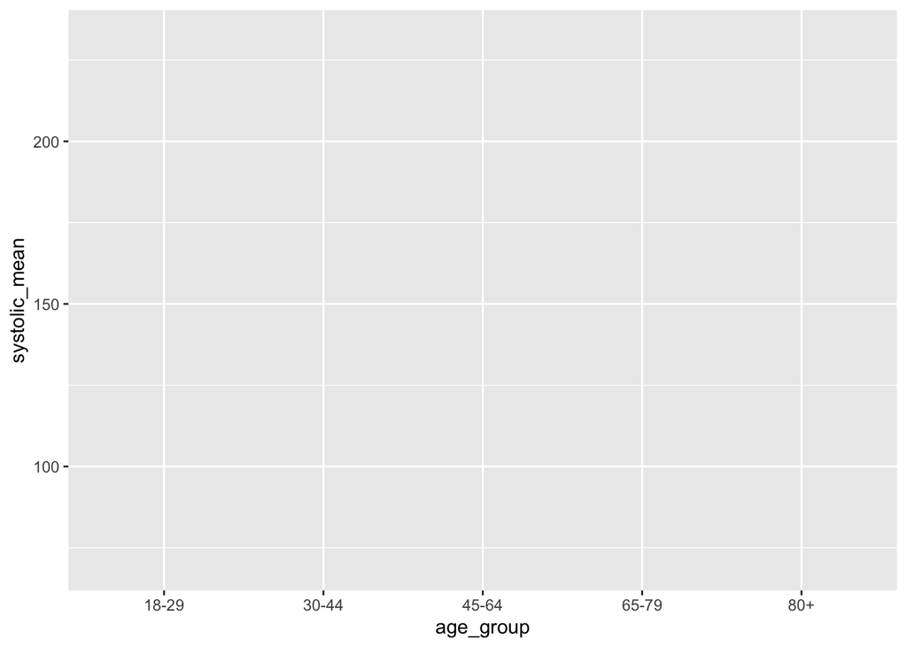

```r
p1 <- ggplot(
  adult_bp,
  aes(x = age_group, y = systolic_mean)
)

p1
```

Add a box plot.

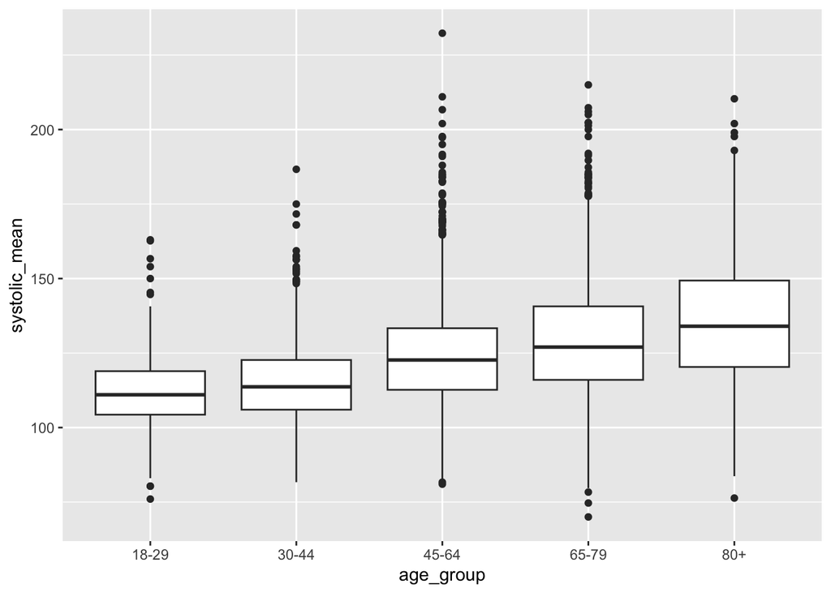

```r
p2 <- p1 +
  geom_boxplot()

p2
```

Add labels and a theme.

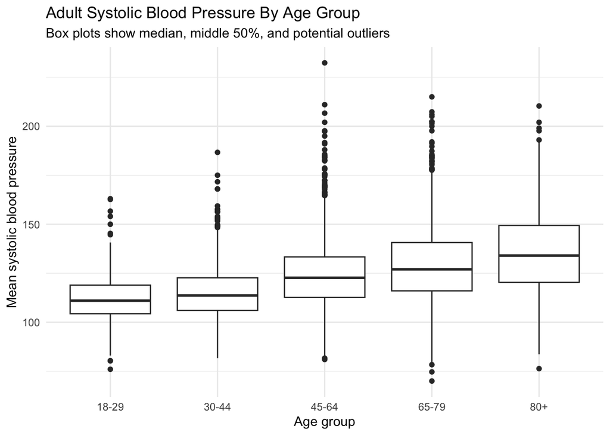

```r
p3 <- p2 +
  labs(
    title = "Adult Systolic Blood Pressure By Age Group",
    subtitle = "Box plots show median, middle 50%, and potential outliers",
    x = "Age group",
    y = "Mean systolic blood pressure"
  ) +
  theme_minimal()

p3
```

Interpretation: older age groups tend to have higher median systolic blood pressure, but there is still substantial overlap across groups.

# Add Points Carefully

Points can show the observations, but they need transparency when there are many rows.

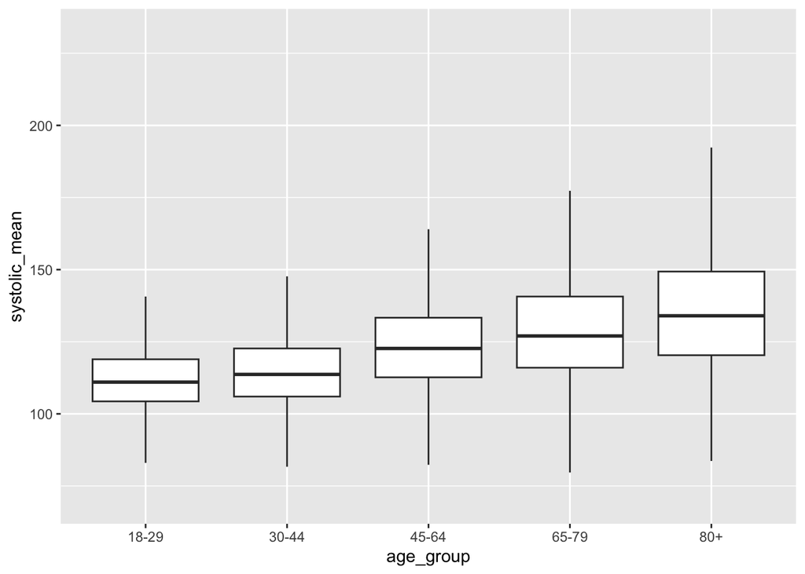

```r
p1 <- ggplot(
  adult_bp,
  aes(x = age_group, y = systolic_mean)
) +
  geom_boxplot(outlier.shape = NA)

p1
```

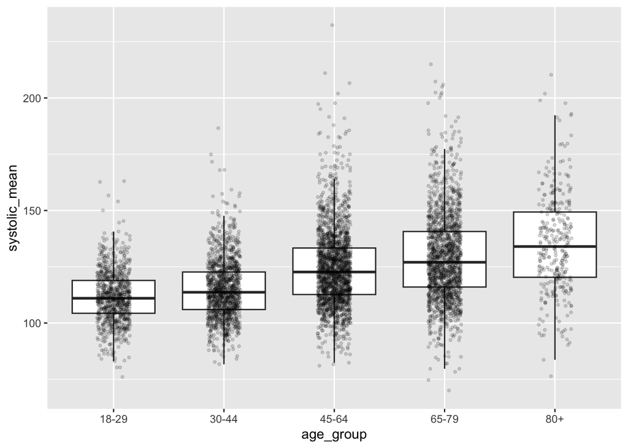

```r
p2 <- p1 +
  geom_jitter(width = 0.15, alpha = 0.15, size = 0.8)

p2
```

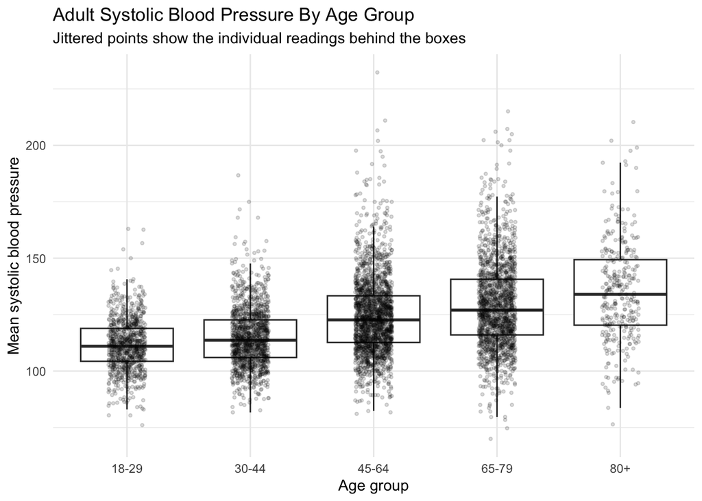

```r
p3 <- p2 +
  labs(
    title = "Adult Systolic Blood Pressure By Age Group",
    subtitle = "Jittered points show the individual readings behind the boxes",
    x = "Age group",
    y = "Mean systolic blood pressure"
  ) +
  theme_minimal()

p3
```

# Violin Plot

Violin plots emphasize distribution shape within each group.

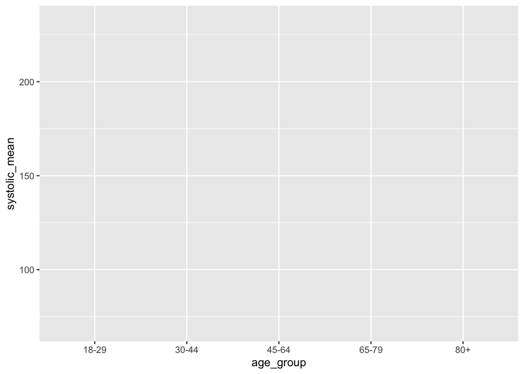

```r
p1 <- ggplot(
  adult_bp,
  aes(x = age_group, y = systolic_mean)
)

p1
```

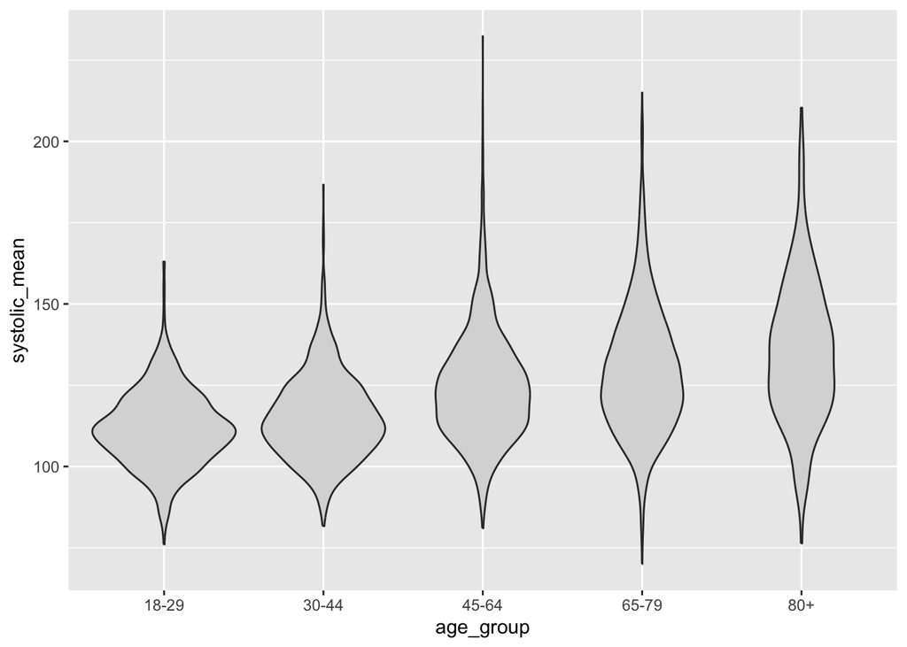

```r
p2 <- p1 +
  geom_violin(fill = "gray85")

p2
```

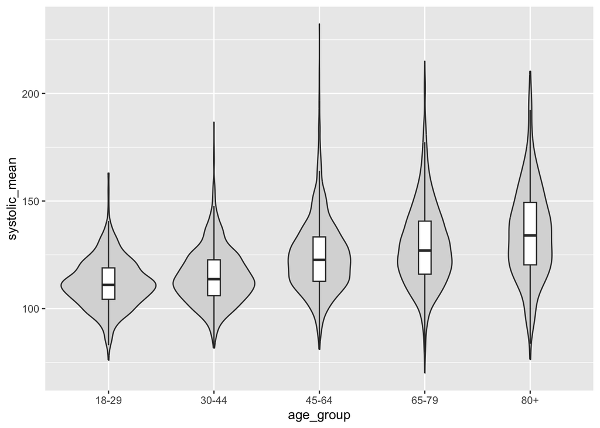

```r
p3 <- p2 +
  geom_boxplot(width = 0.12, outlier.shape = NA)

p3
```

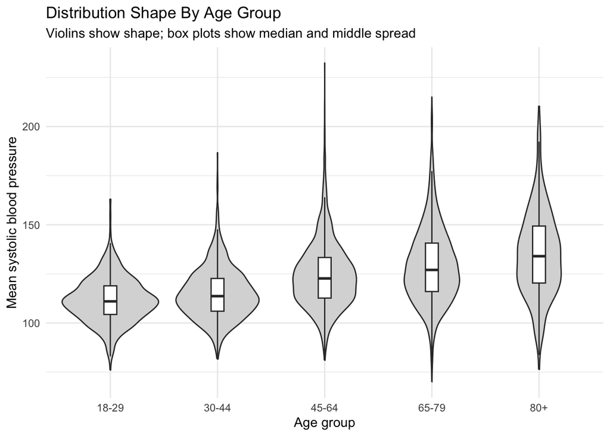

```r
p4 <- p3 +
  labs(
    title = "Distribution Shape By Age Group",
    subtitle = "Violins show shape; box plots show median and middle spread",
    x = "Age group",
    y = "Mean systolic blood pressure"
  ) +
  theme_minimal()

p4
```

# Group Summaries

Summaries help check what the plot suggests.

```r
age_group_summary <- adult_bp |>
  group_by(age_group) |>
  summarise(
    n = n(),
    mean_systolic = mean(systolic_mean),
    median_systolic = median(systolic_mean),
    iqr_systolic = IQR(systolic_mean),
    .groups = "drop"
  )

age_group_summary
```

```
# A tibble: 5 × 5
  age_group     n mean_systolic median_systolic iqr_systolic
  <chr>     <int>         <dbl>           <dbl>        <dbl>
1 18-29       882          112.            111          14.6
2 30-44      1298          115.            114.         16.7
3 45-64      2005          124.            123.         20.7
4 65-79      1618          129.            127          24.7
5 80+         320          135.            134          29.0
```

# Takeaways

- Grouped distribution plots compare more than group averages.
- Box plots are compact and good for median/spread comparisons.
- Violin plots show more shape, but can be harder for new readers.
- Add points only when they improve the plot rather than clutter it.